# HW5

Emma & Ryan

2023-03-06

Team Names: Emma Podlich & Ryan Corydon

Link to Github Repository: https://github.com/epodlich/lab2

## Import Data

```r
library(ggplot2)
choco <- read.csv("https://ds202-at-isu.github.io/labs/data/choco.csv")
head(choco)
```

```
##    Company Specific.Bean.Origin  REF Review.Date Cocoa.Pct Company.Location
## 1 A. Morin          Agua Grande 1876        2016        63           France
## 2 A. Morin                Kpime 1676        2015        70           France
## 3 A. Morin               Panama 1011        2013        70           France
## 4 A. Morin           Madagascar 1011        2013        70           France
## 5 A. Morin               Brazil 1011        2013        70           France
## 6 A. Morin             Equateur 1011        2013        70           France
##   Rating Bean.Type Broad.Bean.Origin
## 1   3.75                    Sao Tome
## 2   2.75                        Togo
## 3   2.75                      Panama
## 4   3.00   Criollo        Madagascar
## 5   3.25                      Brazil
## 6   3.75                     Ecuador
```

## Question Set 1

#### What is the overall number of chocolate bars rated?

The overall number of chocolate bars rated is 1852.

```r
summary(choco)
```

```
##    Company          Specific.Bean.Origin      REF        Review.Date
##  Length:1852        Length:1852          Min.   :   5   Min.   :2006
##  Class :character   Class :character     1st Qu.: 600   1st Qu.:2010
##  Mode  :character   Mode  :character     Median :1099   Median :2013
##                                          Mean   :1065   Mean   :2012
##                                          3rd Qu.:1546   3rd Qu.:2015
##                                          Max.   :2008   Max.   :2017
##    Cocoa.Pct     Company.Location       Rating       Bean.Type
##  Min.   : 42.0   Length:1852        Min.   :1.000   Length:1852
##  1st Qu.: 70.0   Class :character   1st Qu.:3.000   Class :character
##  Median : 70.0   Mode  :character   Median :3.250   Mode  :character
##  Mean   : 71.7                      Mean   :3.191
##  3rd Qu.: 75.0                      3rd Qu.:3.500
##  Max.   :100.0                      Max.   :5.000
##  Broad.Bean.Origin
##  Length:1852
##  Class :character
##  Mode  :character
##
##
##
```

#### How does the number of ratings depend on the year? Draw a bar chart of the number of reports.

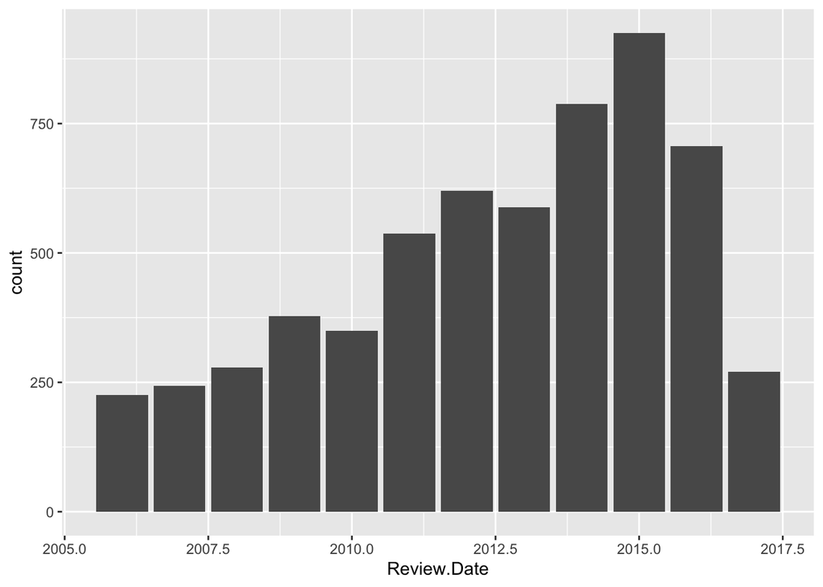

```r
ggplot(choco, aes(x = Review.Date)) +
  geom_bar(aes(weight= Rating))
```

## Question Set 2

### For each of the questions below provide at least one graphic as a basis for your answer.

#### How are ratings distributed? Draw a histogram of ratings and describe it. Don’t forget to mention outliers, if there are any.

Looking at the histogram there seems to be two outliers, a rating with a score of 1 and a rating with a score of 5. The histogram shows the most common ratings are between 2.5 and 4 with the highest being around 3.5.

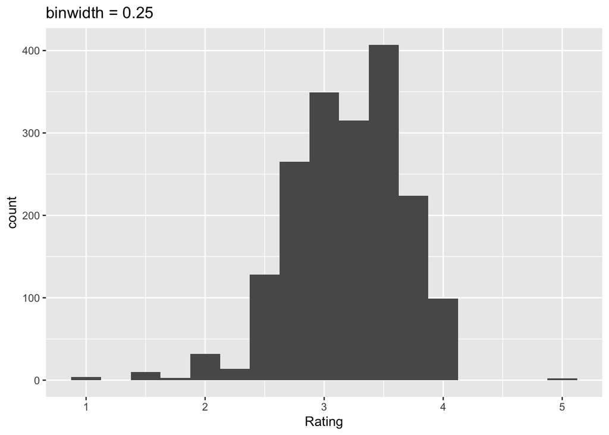

```r
ggplot(choco, aes(x = Rating)) +
  geom_histogram(binwidth=0.25) +
  ggtitle("binwidth = 0.25")
```

#### Do ratings depend on the cocoa percentage of a chocolate bar?

Looking at the scatterplot, we can conclude that ratings do not depend on cocoa percentage. As rating goes increase, cocoa percentage does not either increase or decrease making it an uneven distribution. There is an outlier with a rating of five and the percentage of cocoa is on 70.

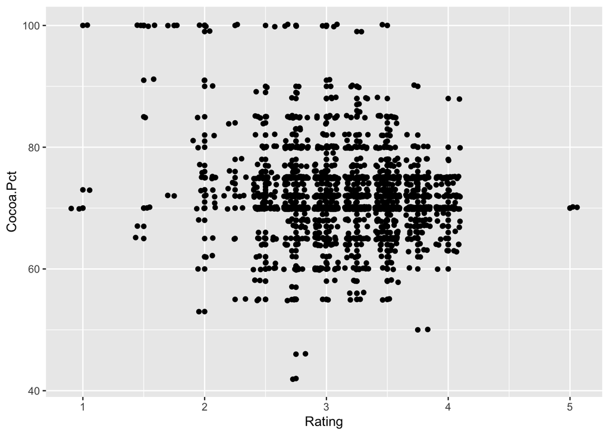

```r
ggplot(data = choco, aes(x = Rating, y = Cocoa.Pct)) + geom_point() + geom_jitter()
```

#### How do ratings compare across different company locations? Focus on the three locations with the most ratings:

The ratings across the different company locations all have about the same median being around a rating of 3.25 and they have about the same maximum rating of 4. However, Canada has the highest 3rd quartile of about 3.75 while both the US and France have 3rd quartiles around 3.5. Also, the 1st quartile of the US is about 2.75 while the 1st quartiles for both France and Canada are about 3. The minimum ratings are the same for the US and Canada with values being around 2 while France’s minimum is about 2.5. There is an outlier in the US of about 1.5 and two outliers in France of about 1.5 and 2. Overall, the ratings are pretty similar across the different company locations.

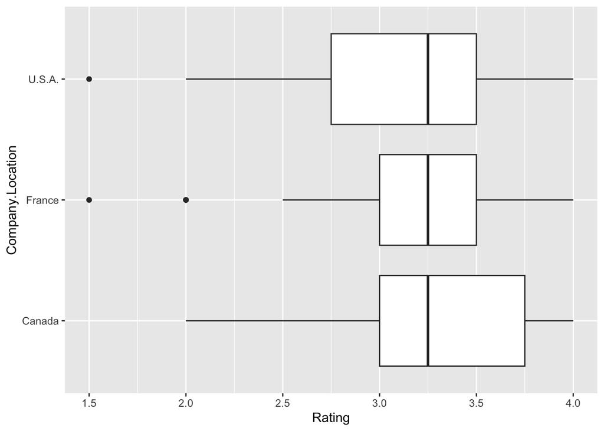

```r
choco.country = dplyr::filter(choco, Company.Location %in% c("U.S.A.", "France", "Canada"))

ggplot(choco.country, aes(x =Company.Location, y = Rating)) + geom_boxplot() + coord_flip()
```

## Our Own Questions

#### Question 1: Emma

How does the Review Date relate to the percentage of cocoa in the chocolate bars? More specifically, are there certain years where a certain percentage of cocoa in the chocolate bars was more popular?

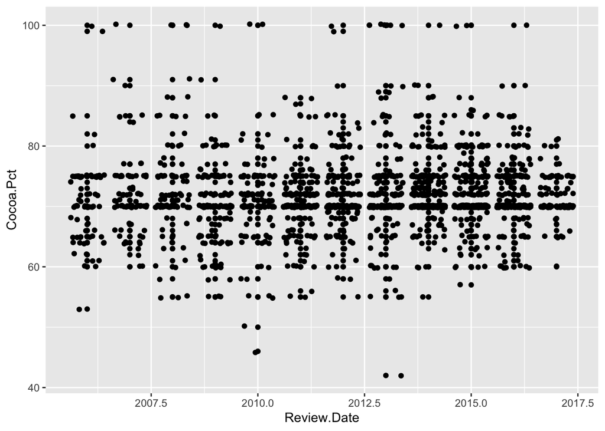

```r
ggplot(choco, aes(x = Review.Date, y = Cocoa.Pct)) +
  geom_point() + geom_jitter()
```

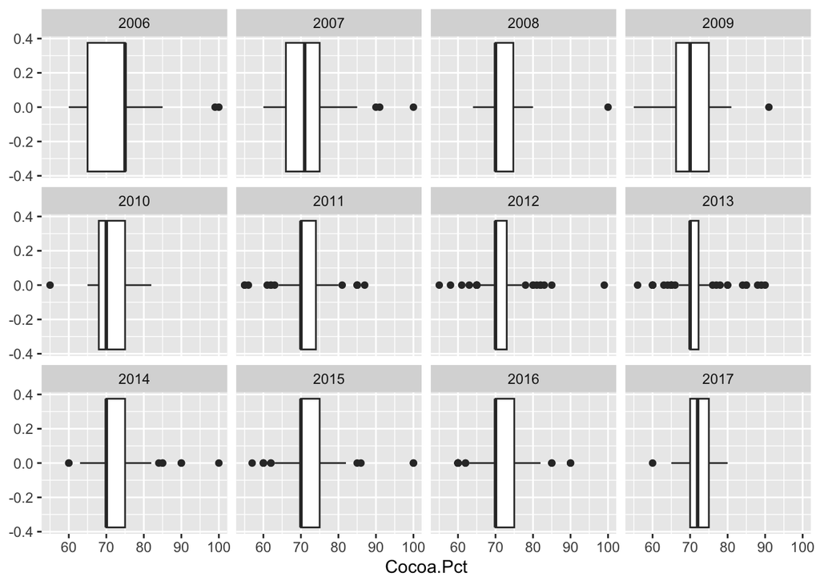

```r
ggplot(choco.country, aes(x = Cocoa.Pct)) + geom_boxplot() + facet_wrap(~Review.Date)
```

Conclusions:

#### Question 2: Ryan

The question I want to investigate is the distribution of cocoa percentage within the total number of chocolate bars.

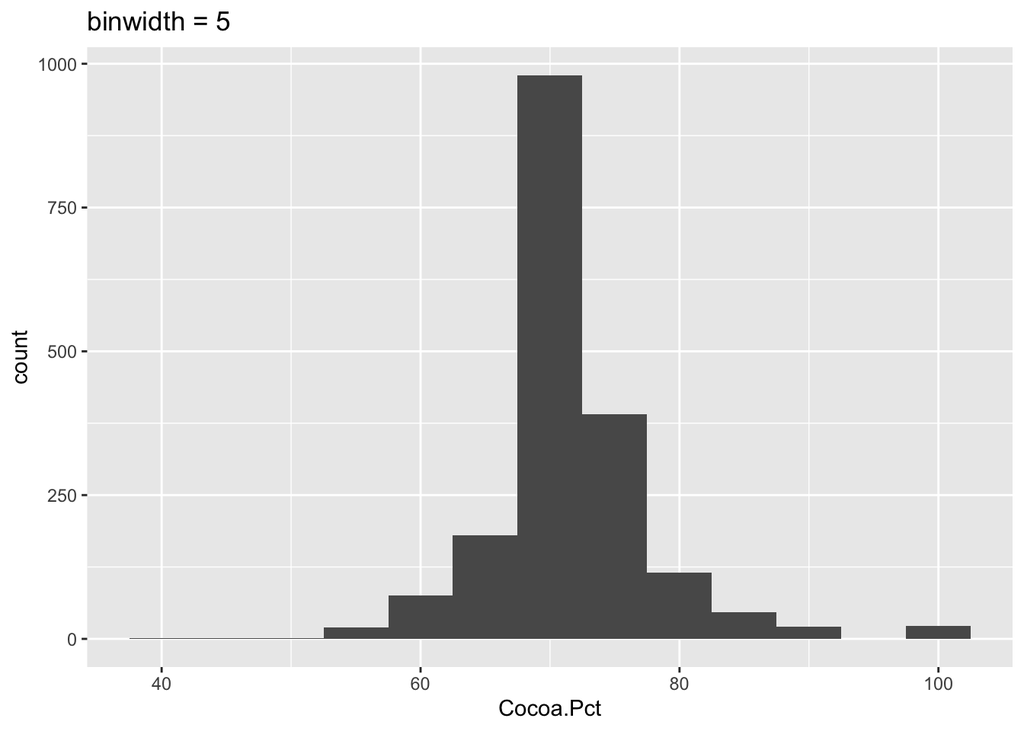

```r
ggplot(choco, aes(x = Cocoa.Pct)) +
  geom_histogram(binwidth=5) +
  ggtitle("binwidth = 5")
```

Conclusions: Through this histogram it can be concluded that most chocolate bars have a cocoa percentage of 70. I can assume the higher the percentage the more richer and sweeter the chocolate bar is. Meaning a bar with 100% cocoa probably does not taste very good. There is an outlier with a few bars that have 100% cocoa in them, as well there is a chocolate bar with only 42% cocoa.

## Workflow

The workflow of this homework assignment went pretty well. We began by creating an outline for this assignment which consisted of the questions that needed to be answered along with R code chunks below each question for writing the code to plot. Then, we both went through and answered the questions that we felt the most confident on. Next, we checked each others work to see if their conclusions and plots made sense. We also discussed possible questions that we would like to explore more and each chose one of the options we created in order to dive deeper into that topic by creating both plots and conclusions. Overall, the flow of the assignment and using github to collaborate went well.